# Git tutorial

## git merge

MergeといえばPR.

GithubでPRをmergeするときはこんな感じのことをしている.

[figure not shown]

```bash
git checkout feature/update_file000
git merge master
```

```bash
$ git log --oneline --graph --all
*   0b45d32 (HEAD -> feature/update_file000) Merge branch 'master' into feature/update_file000
|\
| * 179a3bc (master) Added file001.
* | cf7cb13 Updated file000 (added the second row).
|/
* e170b24 Added file000.
```

Merge commitができている.

```bash
git checkout master
git merge --no-ff feature/update_file000
```

```bash
$ git log --oneline --graph --all
*   500adbb (HEAD -> master) Merge branch 'feature/update_file000'
|\
| *   0b45d32 (feature/update_file000) Merge branch 'master' into feature/update_file000
| |\
| |/
|/|
* | 179a3bc Added file001.
| * cf7cb13 Updated file000 (added the second row).
|/
* e170b24 Added file000.
```

Merge commitがまたできている.

## git mergeをなかったことにする

```bash
$ git log --oneline --graph --all
*   500adbb (HEAD -> master) Merge branch 'feature/update_file000'
|\
| *   0b45d32 (feature/update_file000) Merge branch 'master' into feature/update_file000
| |\
| |/
|/|
* | 179a3bc Added file001. # <-- Merge前のmaterの位置
| * cf7cb13 Updated file000 (added the second row). # <-- Merge前のfeature/update_file000の位置
|/
* e170b24 Added file000.
```

master tagとupdate_file000 tagをそれぞれMerge前の位置に戻せば良い.

## (Interruption) HEADについて

(復習) HEAD^ = 1つ前の親Commit

親が2つ以上ある場合 `HEAD^N (N=親の番号)` のように指定できる.

```bash
$ git show --name-only HEAD^
commit 179a3bce92c28cb9a6ac1ef4d8ff4002c83d2f7d
Author: ameono <4m3on0@gmail.com>
Date:   Sun Feb 17 00:57:33 2019 +0900

    Added file001.

$ git show --name-only HEAD^2
commit 0b45d32e5332152a5a44400d6394344199f4f968 (feature/update_file000)
Merge: cf7cb13 179a3bc
Author: ameono <4m3on0@gmail.com>
Date:   Sun Feb 17 14:51:11 2019 +0900

    Merge branch 'master' into feature/update_file000
```

HEAD~2と似てるけど,全然意味が違う.

```bash
$ git show --name-only HEAD~2
commit e170b24890ca2685d9414b15f3862a28b16b3828
Author: ameono <4m3on0@gmail.com>
Date:   Sat Feb 16 21:28:33 2019 +0900

    Added file000.
```

[figure not shown]

- HEAD~N = HEADのN個前の親Commit
- HEAD^N = HEADの1個前の親CommitのN番目

ex) 1個前の親の2番めの親Commit = HEAD~1^2

- HEAD@{N} = N個前にHEADが指していたCommit

## git mergeをなかったことにする (続き)

masterのMergeをなかったことに

```bash
git reset --hard HEAD^
```

```bash
$ git log --oneline --graph --all
*   0b45d32 (feature/update_file000) Merge branch 'master' into feature/update_file000
|\
| * 179a3bc (HEAD -> master) Added file001.
* | cf7cb13 Updated file000 (added the second row).
|/
* e170b24 Added file000.
```

update_file000のMergeをなかったことに

```bash
git checkout feature/update_file000
git reset --hard HEAD^
```

```bash
$ git log --oneline --graph --all
* 179a3bc (master) Added file001.
| * cf7cb13 (HEAD -> feature/update_file000) Updated file000 (added the second row).
|/
* e170b24 Added file000.
```

簡単ですね?

今までの話が理解できていれば,mergeをなかったことにしたのをなかったことにもできるはず.

## git merge –no-ff について

```bash
(復習)
git checkout feature/update_file000
git merge master
git checkout master
git merge --no-ff feature/update_file000 <-- --no-ffに注目
```

no-ff = No Fast Forward

なしにしてやってみる

```bash
git checkout feature/update_file000
git merge master
git checkout master
git merge feature/update_file000
```

```bash
$ git log --oneline --graph --all
*   e6de5fd (HEAD -> master, feature/update_file000) Merge branch 'master' into feature/update_file000
|\
| * 179a3bc Added file001.
* | cf7cb13 Updated file000 (added the second row).
|/
* e170b24 Added file000.
```

[interactive chart not shown]

**[こわくない Git](https://www.slideshare.net/kotas/git-15276118)** from **[Kota Saito](https://www.slideshare.net/kotas)**

## git rebase

`git rebase [<branch>]`

`git rebase --continue | --skip | --abort | --quit |`

他のbranchの先端に今のbranchの根本から先端までのcommitをまとめて移植する

```bash
# 準備
git branch -f feature/update_file000 HEAD^2
git reset --hard HEAD^
git checkout feature/update_file000
```

```bash
git rebase master
```

```bash
$ git log --oneline --graph --all
* a336ea3 (HEAD -> feature/update_file000) Added file001.
* cf7cb13 (master) Updated file000 (added the second row).
* e170b24 Added file000.
```

```bash
$ git rebase feature/update_file000
First, rewinding head to replay your work on top of it...
Fast-forwarded master to feature/update_file000.

$ git log --oneline --graph --all
* a336ea3 (HEAD -> master, feature/update_file000) Added file001.
* cf7cb13 Updated file000 (added the second row).
* e170b24 Added file000.
```

## git rebaseをなかったことにする

まずはmasterを戻す.

```bash
$ git reset --hard HEAD^
* a336ea3 (feature/update_file000) Added file001.
* cf7cb13 (HEAD -> master) Updated file000 (added the second row).
* e170b24 Added file000.
```

次にupdate_file000を戻す

```bash
$ git reflog
a336ea3 (HEAD -> feature/update_file000) HEAD@{2}: checkout: moving from master to feature/update_file000
cf7cb13 (master) HEAD@{3}: reset: moving to HEAD^
a336ea3 (HEAD -> feature/update_file000) HEAD@{4}: rebase finished: returning to refs/heads/master
a336ea3 (HEAD -> feature/update_file000) HEAD@{5}: rebase: checkout feature/update_file000
cf7cb13 (master) HEAD@{6}: checkout: moving from feature/update_file000 to master
a336ea3 (HEAD -> feature/update_file000) HEAD@{7}: rebase finished: returning to refs/heads/feature/update_file000
a336ea3 (HEAD -> feature/update_file000) HEAD@{8}: rebase: Added file001.
cf7cb13 (master) HEAD@{9}: rebase: checkout master
179a3bc HEAD@{10}: checkout: moving from master to feature/update_file000 # <-- これ
```

```bash
$ git reset --hard HEAD@{10}
$ git log --oneline --graph --all
* 179a3bc (HEAD -> feature/update_file000) Added file001.
| * cf7cb13 (master) Updated file000 (added the second row).
|/
* e170b24 Added file000.
```

Mergeより戻すのが面倒(reflog使わないかん)ですね.

このことから,rebaseとmergeならmergeを使うべきという人もいます.

公式曰く,

> 公開リポジトリにプッシュしたコミットをリベースしてはいけない

> この指針に従っている限り、すべてはうまく進みます。もしこれを守らなければ、あなたは嫌われ者となり、友人や家族からも軽蔑されることになるでしょう。(Pro Git)

## Merge VS rebase

[interactive chart not shown]

**[こわくない Git](https://www.slideshare.net/kotas/git-15276118)** from **[Kota Saito](https://www.slideshare.net/kotas)**

## 歴史改変のrebaseとbranchのrebase

歴史改変のrebase(左)とbranchのrebase(右) やっていることは同じ.

[figure not shown]

## git cherry-pick

`git cherry-pick <commit>...`

他のbranchの特定のcommitを今のbranchの先端に移植する

```bash
$ git log --oneline --graph --all
* 179a3bc (HEAD -> feature/update_file000) Added file001.
| * cf7cb13 (master) Updated file000 (added the second row).
|/
* e170b24 Added file000.
```

```bash
$ git cherry-pick cf7cb13
```

```bash
$ git log --oneline --graph --all
* 8a1eae4 (HEAD -> feature/update_file000) Updated file000 (added the second row).
* 179a3bc Added file001.
| * cf7cb13 (master) Updated file000 (added the second row).
|/
* e170b24 Added file000.
```

`master`のcommitが`feature/update_file000`へcopyされた

rebaseはcherry-pickを複数まとめてやっているだけとも言える.

## Conflict

```bash
# 準備
git reset --hard HEAD^
echo "ROW002 <- update_file000" >> file000
```

```bash
$ git merge master
Auto-merging file000
CONFLICT (content): Merge conflict in file000
Automatic merge failed; fix conflicts and then commit the result.
```

```
ROW000
<<<<<<< HEAD
ROW002 <- update_file000
=======
ROW001
>>>>>>> master
```

## Conflictの解消法

1. ConfilitしたファイルをEditerで編集する
2. `git checkout [--theirs|--ours] <paths>` を使う
3. merge-toolを使う

## 1. ConfilitしたファイルをEditerで編集する

そのまんま. Vimとかでひらいて↓こんな感じに編集して保存,AddしてCommit

```
ROW000
ROW002 <- update_file000
```

## 2. checkoutを使う方法

```bash
git checkout --theirs file000
```

```
ROW000
<<<<<<< HEAD # = --ours
ROW002 <- update_file000
=======
ROW001
>>>>>>> master # = --theris
```

merge元のbranch(=–theirs)の変更かmerge先(=HEAD, –ours)の変更かのどちらかを採用する.

**利点**: pdfや画像などテキストとして編集できないものがConflictしたときに便利

PDFをVimで開いて「この行はmerge先を採用して,こっちはbranchを採用…」とかやってるやつがいたら病気…

**欠点**: どういう結果になるか予想がつきにくい.

## 3. merge-toolを使う

merge-toolには[色々ある](https://japan.blogs.atlassian.com/2016/02/tips-tools-to-solve-git-conflicts/).

```
git mergetool --tool=vimdiff
```

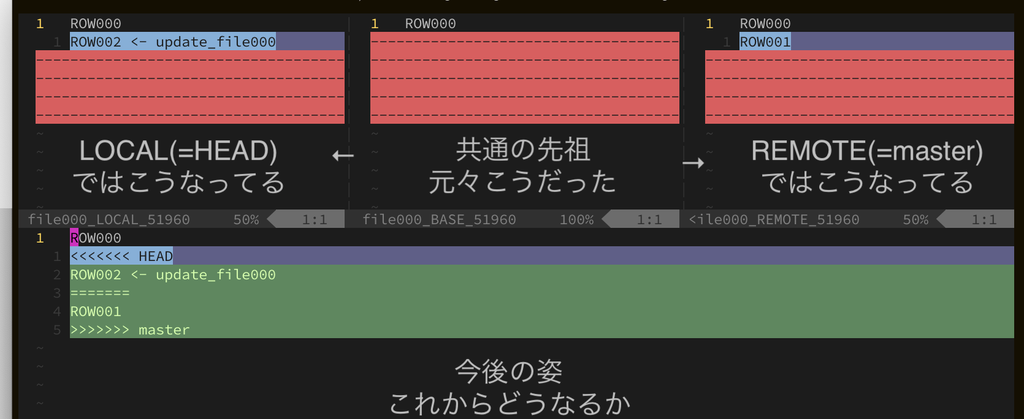

DiffがあるChunk(=色が変わっている部分)にカーソルを合わせ, 1do, 2do, 3doと入力することで,それぞれ上段の左から1番目,2番目,3番目が今後の姿に取り込まれる.

PyCharmのようにConflictを解消するツールが付いているIDEもある.

[figure not shown]

## Github

## Githubってなんだよ

GitHub は世界最大の Remote Git リポジトリホスティングサービスだよ.

つまり?

**localのrepository = localのPCにおいてあるdirecotry**

とすると,

**Github上のrepository = Google driveにおいてあるdirecotry**

のような関係.

有名どころ

- Github
- Gitlab
- Bitbucket

Githubがやたら有名だが他にもある (Google driveとDropbox的な関係).

できることは大差ないので,お財布事情とUIの好みの問題

(あとは狸と猫のどっちが好きかとか…バケツ…).

[figure not shown]

### Github

- とにかく有名 (連携サービスが多いイメージ).
- お金たくさん持ってく.
- [Github Education](https://education.github.com/)とか言う学生プランに加入するとGithub含め色々な有名サービスが無料で使える.
- 本田圭佑がいる
- 他の2つと違い自前のCIとかはない(他のツールと組み合わせる前提OSSの思想的には○?)

### Gitlab

- どちらかというと,自組織のサーバにインストールして自分たちしかアクセスできないRemote repositoryとして使う (要するに自前のfile server的なやつ)オンプレミス版のほうが有名.
- Slackを水で薄めたようなchatアプリやCIがついてくるので,これひとつで開発に必要なすべての作業を完結させることができる.
- 大人の事情でPublic臭の強いGithubとかSlackとかを使えない人たちが使ってるっぽい(NASAとか).

### Bitbucket

- 一昔前までPrivate repository(外部公開されない) 作り放題な唯一のサービスだったので,個人の利用者が多くいた(今は,Githubも作り放題).
- Source treeの開発元でもあるAtlassianの製品.
- お金ないらしい(最近値上げした).

### 比較

https://stackshare.io/stackups/bitbucket-vs-github-vs-gitlab

2019 2月現在,各サービスの無料プランの状況

|  | Github | Bitbucket | Github (学生) | Bitbucket (学生) | GitLab |
| --- | --- | --- | --- | --- | --- |
| private repository | 無制限 | 無制限 | 無制限 | 無制限 | 無制限 |
| public repository | 無制限 | 無制限 | 無制限 | 無制限 | 無制限 |
| collaborator | 3名まで | 5名まで | 無制限 | 無制限 | 無制限 |
| CI build time | - | 50分/月 | - | 500分/月 | 2000分/月 |
| LFS | 1GB | 1GB | 1GB | 5GB | 無制限? |
| LFS Bandwidth | 1GB/月 | 無制限 | 1GB/月 | 無制限 | 無制限? |

## git clone

remote repositoryのcopyをlocalに作る.(= Download)

`git clone <repository>`

[figure not shown]

最初の一回しか使わない(あとはpullやfetch).

## git fetch

現在のremoteの`<branch>` refsの位置に合わせてlocalの`origin/<branch>` refsの位置を更新する.

`git fetch <remote> <branch>`

[figure not shown]

## git fetch

```bash
git merge origin/master
```

[figure not shown]

## git pull

remote branchの変更をlocalのbranchに取り込む (Downloadに近い)

`git pull [--rebase|--no-ff] <remote> <branch>`

`git fetch` と `git merge origin/master` をまとめてやる(`--rebase`つけると`git rebase origin/master`になる)

[figure not shown]

Mergeの作業が入っているため,pullではConflictが発生する可能性がある.

PRという名前はGithubのPRのMergeにpull(fetch+merge)コマンドが含まれることに由来する

## git push

local branchの変更をremote branchに反映させる (Uploadに近い)

`git push <remote> <branch>`

git pullのremoteとlocalを逆にしたもの(pullと違いConflictする場合は実行できない= –ff-only).

[figure not shown]

## git pushできないとき

何れかの原因でConflictする場合,pushはできないので適切な方法で対処する

### 自分に原因がある場合

- 原因となる作業: rebase, commit –amend, resetなどremoteとconflictする作業をした
- 対処法: `git push -f <remote> <branch>`, `git push --force-with-lease <remote> <branch>` で強制pushする

`git push -f` は強制的にremoteを上書きするので,ミスると**remoteからすべての歴史を吹き飛ばす**ので(頭真っ白になる), 吹き飛ばしても人に迷惑のかからないfeature branchのみで使うこと.

`--force-with-lease` オプションはローカルのrefsがremoteと一致している場合のみ(i.e., localが最新の場合)強制的にremoteを上書きするのでやや安全

### 他人に原因がある場合

- 原因となる作業: 同じbranchに他のCollaboratorがpushした
- 対処法: `git pull <remote> <branch>` してConflictを解消してからpushする (pullはconflictが起こっても実行できるため)

## git fetch VS git pull

- 他のbranchにcheckoutせずにremoteのCommitを取り込みたい場合fetch
- それ以外の場合pull

最新のmasterにfeatureをrebaseしたい場合の例

```bash
# pull version (HEAD -> feature)
git checkout master
git pull origin master
git checkout feature
git rebase master
```

```bash
# fetch version (HEAD -> feature)
git fetch origin
git rebase origin/master
```

は?

特に,HEADに未commitのfileがあるときにこれをやりたくなるとpullでは非常に面倒(stashを使えばいいのだが更に2コマンド増える)

## Git Flow

branchをどのように切るか(branch戦略)を決めるstyleの一つ.

別に守らなくてもErrorは起きないが,守ると便利なルール(Coding styleとかと同じ立ち位置).

[figure not shown]

- **feature**:
  - 作業用branch
  - Issueをassignされた人が好きにして良い
  - Issueと対応しているとbetter
- **master**:
  - relase専用のbranch
  - ここに直接CommitしたりfeatureをMergeすることはない
- **develop**:
  - feature branchをmergeする専用のbranch
  - ここに直接commitすることはない
- **(hotfixes)**:
  - masterに緊急のbugが見つかったときに修正のcommitをするbranch
- **(release)**:
  - masterにmergeする直前の作業をするbranch

## Github Flow

[figure not shown]

featureとmasterしかないシンプルなFlow.

面倒なことはPR上でやる.

## Gitlab flow

[figure not shown]

- **feature/hotfix**: 機能開発、不具合対応branch
- **master**: mainのbranch
- **pre-production(option)**: release前のtest用(git-flowで言うrelease branch)
- **production**: release済みのcode置き場

## 原稿執筆に利用する場合

正解はないので,その都度最適な戦略を考えて選択するべきだが,一例として以下のようなものを提案しておく.

- **feature**: 原稿の執筆を行う
- **develop (master)**: featureのMerge用(Introを書き終えたとかのタイミングでMergeしていくイメージ)
- **master (production)**: 研究会, 国際会議とかの完成版原稿をおいておく

1つの研究の原稿は同じRepositoryで管理し,研究会->国際会議->修論などのようにVersionアップするたびにreleaseしていくといいんじゃない?

## Taboo and recommended actions

## Gitでやってはいけないこと

### sizeのでかいファイルをcommitに含める

cloneするのにすごく時間がかかるようになります.

やっちゃったら[Gitの内側 - メインテナンスとデータリカバリ](https://git-scm.com/book/ja/v1/Git%E3%81%AE%E5%86%85%E5%81%B4-%E3%83%A1%E3%82%A4%E3%83%B3%E3%83%86%E3%83%8A%E3%83%B3%E3%82%B9%E3%81%A8%E3%83%87%E3%83%BC%E3%82%BF%E3%83%AA%E3%82%AB%E3%83%90%E3%83%AA)を参考に当該のファイルを削除する(失敗するとCommitツリーを破壊するリスクがあるのでしないにこしたことはない)

Tips: [Git LFS](https://git-lfs.github.com/) という大容量バイナリファイルを扱う方法も提供されている

### developやmasterでrebaseする

feature**で**developやmaster**を**rebaseするのはおk

### developやmasterで`git push -f`する

Githubでは,push -fできないようにbranchをprotectすることも可

やってしまっても大概なんとかなるけど,他の人にすごく迷惑がかかるので,喧嘩売りたいとき以外はやめましょう.

## Gitで積極的にやるべきこと

### 即Issueを起てる,即Branchを切る

何かしようと思ったらとりあえずIssue起てる.

### Commit messageにIssue番号を含める

`Added some files. #1` のようにすると1番のIssueのページから当該のCommitが見れるようになりトラッキングが楽.

### 労う

よいPRには,LGTM (Looks Good To Me) を送りましょう.

[figure not shown]

## Conclusion

## Conflictが起こる可能性のあるcommands

- merge
- rebase
- pull (commandの一部にmergeを含むため)
- push (–ff-onlyなのでConflictが起こるとコマンドは失敗する)

## Exercise

## Exercise

1. (私が)HPの自己紹介文の更新みたいなタスクでIssue起てる
2. PC内の適当なところに`git clone https://github.com/h1r0mu/git-tutorial.git`
3. `git branch feature/issue番号-自分の名前` とかでbranchを切ってcheckout
4. `slide/body/内に`自分の名前.mdを作って,Markdownのリストで自己紹介文を書く
5. AddしてCommitしてPushしてPR出す
   - Commit messageを`Added a self-introduction slide. #<Issue番号>`のようにする
6. コメントをつけるので,修正してPushする
- 他の人のPRがMergeされたらpullでmasterを更新してfeatureにrebaseする

### Markdownの箇条書きリストの書き方

```markdown
- リスト1
    - ネスト リスト1_1
        - ネスト リスト1_1_1
        - ネスト リスト1_1_2
    - ネスト リスト1_2
- リスト2
- リスト3
```

## Advanced

## gitの小技N本ノック

[gitの小技N本ノック](https://yukihira1992.github.io/git-tricks/)

特に以下の3つのコマンド(keyword)については一読しておいたほうが良い.

- stash
- revert
- submodule (これとgit clone –recursiveを知らないと人のGithubのコードをcloneして使うときとかに詰まることが稀によくある)

## References

## 勉強に使えるサイト

[Pro Git](https://git-scm.com/book/ja/v2)

- [Git公式サイト](https://git-scm.com/)の管理者が書いた本(無料で見れる)
- 一次資料に近い情報なので一通り読むことが推奨される(ちょっと仔細にわたり過ぎているきらいはあるのでいきなり読まないほうが良いかも)
- 日本語(もある)

[Git をはじめからていねいに](https://github.com/Shinpeim/introduction-to-git)

- 手を動かしながらGit commandを学べる
- 詳しすぎず雑すぎずちょうどよい説明
- 日本語

[Learning Git Branching](https://learngitbranching.js.org/?locale=en)

- GitのBranchをシミュレートしてくれるWeb application
- 一通りのBranch操作のチュートリアルがある
- Branchを視覚的に理解する役に立つ
- Chromeだと表示がおかしくなる(Firefoxは平気だった)
- 英語(日本語もあるけどなんかバグってる)